# Survival-Supervised Bayesian Matrix Factorization for Prognostic Molecular Programs in Pancreatic Cancer

Author

Andrew Walther

Published

November 13, 2026

# Summary

**Aim.** Bulk pancreatic tumors mix tumor, stromal and immune signals. We ask whether a Bayesian matrix factorization that lets survival inform its molecular programs can find prognostic programs that an unsupervised factorization misses, and whether its risk score transfers to new cohorts.

**Method.** The model factorizes expression into patient activities and gene loadings and links survival through a Cox model on the projection of each patient’s expression onto the loadings. A survival weight $w_S$ sets how much the Cox partial likelihood is weighted relative to the expression likelihood. The primary comparator uses the same factorization at the same rank fitted without survival, followed by a Cox model on its program scores.

**Results.** The working model is the supervised YFB fit ($w_S = 1$, 2,218 genes, rank 5). On the 273 training patients its five-fold cross-validated concordance within cohort was 0.655 (SE 0.028), and every fold fit converged. Scored once on 5 external series, its mean concordance was 0.630 (95% donor-bootstrap interval 0.587 to 0.670), and 3 of its 5 programs were survival-active (Section 4.1). The supervised and two-step fits had small estimated performance differences (Section 4.2). Counting all pairs in each held-out fold, their mean fold concordances were 0.660 and 0.656, a paired difference of +0.004 (SE 0.004), and their mean external concordances were 0.630 and 0.631, a pooled paired difference of −0.001 (95% donor-bootstrap interval −0.010 to 0.008). The largest median survival share of loading precision across programs, gene-set sizes and fits was $9 \times 10^{-7}$, and the supervised and unsupervised loadings correlate at 1.000. Against DeSurv, elastic-net Cox and PurIST, all trained on the same patients, every paired difference in mean external concordance had a 95% interval that included zero (Section 4.9). In simulations fitted at rank 7, supervision matches the two-step fit when a prognostic program is easy to find, and it improved recovery near the detection threshold under strong survival. Choosing the weight by cross-validated partial log-likelihood on the training data kept $w_S = 1$. The fit is not pruned, because ELBO pruning lost the planted program in simulation, and its rank comes from training cross-validation.

**External cohorts.** Under the current rule, modeling choices are made by simulation and five-fold cross-validation on the 273 TCGA and CPTAC training patients. This covers preprocessing, gene screening, priors, rank, survival weight and comparator tuning. The five external expression series and the matched ICGC methylation set only score a model that is already fixed. Earlier development used external concordance to choose the screen and scaling, to pool the training cohorts without a cohort indicator and to constrain the starting values, so these series are not untouched validation data (Section 2.2). Training cross-validation kept the gene screen and the per-cohort standardization and selected rank 5 for the working model (Section 4.7).

**Work of November 9–13.** The analyses of this week compare priors on the loadings and the survival coefficients, fit methylation alone, test one fitter for several data types, compare two ways of linking survival to the programs, and reselect the gene screen, input scaling and rank on training data. The current model keeps point-Laplace priors on the scores and loadings and a Normal prior on each survival coefficient (Appendix D). It also keeps the gene screen and the z-scores within cohort, and the one-standard-error rule selects rank 5 (Section 4.7). At rank 5 the projection and latent-score models had small paired differences in training and external concordance, and the projection model is kept (Section 3.5). Methylation alone, on 144 matched TCGA patients, had mean cross-validated concordance of 0.50 to 0.55, close to 0.5. It was below expression on the same patients in all 7 comparisons, but only 3 differences exceeded two paired standard errors. It found no survival-active program that the expression fit lacks. Its programs share two strong directions with the expression programs, and a few recurring programs are specific to methylation (Section 3.3). Preliminary results for the feature-group fitter and its descriptive matched-TCGA comparison are reported in Section 3.4.

# 1 Methods

## 1.1 Notation

Patients are indexed by $i = 1, \dots, n$, genes by $j = 1, \dots, p$ and programs (factors) by $k = 1, \dots, K$. Patient $i$ has observed time $t_i$ and event indicator $\delta_i$ (1 for death, 0 for censoring). The training data are an $n \times p$ expression matrix $Y$. For a random quantity $\theta$ under the variational posterior $q$, $\bar\theta = E_q\theta$.

Two patient-level quantities are kept apart. The **activities** $L \in \mathbb{R}^{n \times K}$ are posterior scores in the reconstruction $Y \approx LF^\top$ and exist only for training patients. The **program scores** $Z = Y\bar F$ are the product of a patient’s expression with the posterior-mean loadings. They enter the Cox predictor and can be computed for any new patient whose expression is measured on the same genes.

## 1.2 Model

The expression matrix is modeled as
$$y_{ij} = \sum_{k=1}^K L_{ik} F_{jk} + e_{ij}, \qquad e_{ij} \sim N(0, \tau_j^{-1}),
\tag{1}$$
with independent point-Laplace priors on the entries of each column of $L$ and $F$, a point mass at zero mixed with a Laplace distribution, whose parameters are estimated by empirical Bayes within each program with the R package ebnm (Willwerscheid et al. 2025). Each gene has its own residual precision $\tau_j$. Survival follows a Cox model (Cox 1972) whose linear predictor is the program-score projection,
$$\eta_i = \sum_{k=1}^K Z_{ik}\beta_k, \qquad Z = Y\bar F, \qquad \beta_k \sim N(0, \sigma_k^2),
\tag{2}$$
with the prior variance $\sigma_k^2$ estimated per program. This is the YFB model, named for its predictor $\eta = (YF)\beta$. Because new patients are scored by the same projection, prediction needs no refitting.

The variational objective is
$$E_q \log p(Y \mid L, F, \tau) \;+\; w_S\, E_q \log \mathrm{PL}(\beta, F) \;-\; \mathrm{KL}(q \,\|\, \text{prior}),
\tag{3}$$
where $\mathrm{PL}$ is the Cox partial likelihood. The survival weight $w_S$ multiplies the Cox term wherever it appears: in the loading update, in the coefficient update and in the objective. At $w_S = 1$ the objective is the evidence lower bound of the joint model. Larger values of $w_S$ give survival more influence on the loadings. The full derivation, with every update checked term by term against the code, is in `derivations/SSBMF-YFB-model-derivations/SSBMF-YFB-model-derivation-full.pdf` (Appendix A).

**Scale.** The reconstruction does not fix the scale of a program: multiplying $L_{\cdot k}$ by $c$ and dividing $F_{\cdot k}$ by $c$ leaves $LF^\top$ unchanged. The fit therefore rescales each nonzero program after a sweep so that its posterior mean training projection has standard deviation 1. Each $\beta_k$ is then a log hazard ratio per standard deviation of the program score, and a single $w_S$ means the same thing for every program.

## 1.3 Fitting and prediction

Each sweep re-expands the Cox partial likelihood to second order around the current $\bar\eta$, with the predictor’s variance taken from $q(\beta)$ and $q(F)$. It then updates, one program at a time, the coefficient, the activities and the loadings. The loading update uses the reconstruction residual and the weighted Cox contribution to its precision and linear term. Each sweep ends by updating the noise precisions and rescaling the programs. The fit starts from the singular value decomposition of $Y$ and stops when the relative change in the objective falls below $10^{-5}$ or after 300 sweeps. The working fit is not pruned (Section 4.8) and has rank 5 (Section 4.7).

New cohorts are standardized gene by gene within cohort and scored on the training genes they measure. The direction of the risk score is the one the fit learns from training survival. There is no post-fit sign correction: a fit oriented the wrong way would have training concordance below 0.5 and is reported as fitted.

## 1.4 The two-step comparator

The rank-matched comparison uses the same fitter at $w_S = 0$, which removes survival from the loading update and gives the unsupervised empirical-Bayes factorization at the same rank, on the same genes and patients. Because $w_S$ also multiplies the Cox term in the coefficient update, $w_S = 0$ gives $\beta = 0$. The two-step comparator therefore takes the $w_S = 0$ loadings and fits an unpenalized Cox model on the training program scores. It differs from the supervised fit only in whether survival entered the loadings and in how $\beta$ was estimated.

## 1.5 Choosing the survival weight

The real-data fit uses $w_S = 1$, fixed by five-fold training cross-validation (Section 4.6). Two refinements were tested in simulation. In the survival-block form, $w_S$ multiplies the Cox term and the Kullback–Leibler term of $\beta$ together, so $\beta$ gets an ordinary Bayesian Cox fit while the loadings see survival at weight $w_S$. The weight is chosen for each dataset from $\{1, 2, 5, 10, 20, 50\}$ by five-fold cross-validated partial log-likelihood, with ties going to the smaller weight. The same rule was applied to the real training data (Section 4.6).

## 1.6 Choosing the gene screen, input scaling and rank

The gene screen and the input scaling were compared with alternatives by five-fold training cross-validation on the folds of Section 4.2, using concordance within cohort. The current screen is the 2,218-gene set described in Section 2.1. The alternative is a different preprocessing configuration, not only a different ranking rule. It z-scores each cohort, quantile-normalizes the merged matrix and keeps the 2,000 genes of largest variance. Neither screen uses outcomes, so each was computed once on all training patients, as in DeSurv. The alternative scalings divide each gene by its within-cohort standard deviation, with the Cox projection centered, or apply the within-patient rank transform of DeSurv followed by z-scores within cohort (Young et al. 2026). The current choice was kept unless an alternative was better by more than one standard error of the paired fold difference.

The rank is not chosen by ELBO pruning, which lost the planted program in simulation (Section 4.8). We chose it by five-fold training cross-validation with the one-standard-error rule. The rule takes the smallest $K$ from 2 to 12 whose mean concordance is at least the best mean minus the standard error of the fold concordances at the best $K$. Without pruning the fit keeps every column it starts with, so cross-validation chooses the fitted rank.

## 1.7 The models behind the reported results

The working model is the supervised YFB fit ($w_S = 1$, 2,218 genes, rank 5). It is `fit_ssbmf_yfb(canonicalize = TRUE, w_S = 1)` on the 2,218-gene set, with every RNA-seq cohort logged once and z-scored gene by gene within cohort, 5 programs without pruning, point-Laplace priors on $L$ and $F$ and a Normal prior on $\beta$. The survival weight, the gene-set size, the choice not to screen genes on survival, the priors and the rank were fixed by training cross-validation. The gene screen and the input scaling were first set with external concordance (Section 2.2), and training cross-validation has since kept both (Section 4.7). External concordance also informed two earlier choices: pooling the training cohorts without a cohort indicator and the constraints on the singular value decomposition used to start the fit. Its training cross-validation, survival-active programs and external concordance are reported in Section 4.1.

Every result for the real data comes from this fit, except the comparison of the gene screen and input scaling (Table 13) and the prior comparisons (Appendix D). These use the rank-7 reference, the same supervised YFB configuration ($w_S = 1$, 2,218 genes) fitted at rank 7, and say so. The five programs of the rank-5 fit match Programs 1 to 5 of the rank-7 reference one to one (Table 23 in Appendix C). Rank-7 Programs 6 and 7 have no rank-5 counterpart, and neither was survival-active.

# 2 Evaluation

## 2.1 Data

Table 1: Training and validation cohorts. Patient and death counts are read from the saved fold table and external scoring results. Scores omit training genes absent from the external series. PACA-AU is the Australian pancreatic cancer project of the International Cancer Genome Consortium (ICGC). Its array and RNA-seq series share donors. TCGA-PAAD, The Cancer Genome Atlas pancreatic adenocarcinoma cohort. CPTAC, Clinical Proteomic Tumor Analysis Consortium. RNA-seq, RNA sequencing.

| Cohort | Platform | Patients | Deaths | Missing genes | Role |
| --- | --- | --- | --- | --- | --- |
| TCGA-PAAD | RNA-seq | 144 | 75 | 0 | Training |
| CPTAC | RNA-seq | 129 | 64 | 0 | Training |
| Dijk | RNA-seq | 90 | 81 | 30 | External validation |
| Moffitt | Microarray | 123 | 83 | 71 | External validation |
| PACA-AU array | Microarray | 63 | 38 | 13 | External validation |
| PACA-AU RNA-seq | RNA-seq | 52 | 31 | 27 | External validation |
| Puleo | Microarray | 288 | 181 | 82 | External validation |

The model is trained on 273 patients (139 deaths) from two RNA-seq cohorts, TCGA-PAAD and CPTAC (Table 1). Every RNA-seq cohort is transformed once by $\log_2(x+1)$. Genes are screened separately in each training cohort by the combined mean and variance rank of DeSurv (Young et al. 2026), keeping the top 3,000 per cohort. The screen uses no outcomes. The intersection, called the 2,218-gene set, has 2,218 genes. Each cohort is then standardized gene by gene to mean 0 and standard deviation 1.

The 5 external series supply 616 records and 414 recorded deaths. The PACA-AU array and RNA-seq series share 47 donors, and the RNA-seq series has 52 records from 51 donors, so the external collection represents 568 people if the other cohorts are distinct (counts from the October 16 accuracy review, `paper/writeup/2026-10-16-writeup/_process/Accuracy_Review_Dispositions_10_16_26.md`).

## 2.2 Uses of the external cohorts

The current selection rule uses simulation and five-fold cross-validation on the 273 TCGA and CPTAC training patients. This includes preprocessing, gene screening, the priors, the rank, the survival weight and the tuning of comparators. The five external expression series (Dijk, Moffitt, PACA-AU array, PACA-AU RNA-seq and Puleo) and the matched ICGC methylation set only score a model after it is fixed. Under this rule, their results are reported and do not choose between models or settings. The DeSurv comparator used its published settings rather than a new search on our folds. Four choices were made before this rule with external concordance among the evidence: the gene screen, the per-cohort standardization without a rank transform, pooling the training cohorts without a cohort indicator and the constraints on the singular value decomposition that starts the fit. Training cross-validation has since kept the screen and the standardization and selected rank 5 (Section 1.6, Section 4.7). The audit in `docs/findings/2026-11-06-external-cohort-uses.md` records which earlier choices used which series. It also notes that the matched ICGC methylation set overlaps the PACA-AU donors and has been examined in earlier analyses.

The rule follows the protocol DeSurv used on the same cohorts (Young et al. 2026). DeSurv was trained on TCGA and CPTAC pooled. Every hyperparameter was chosen by five-fold cross-validation on the training data, with the one-standard-error rule for the rank, and the external cohorts were scored once with the final model. No portion of the training data is held out here either. With 273 patients, a held-out fifth would estimate concordance with a standard error near 0.05, larger than the differences between the settings being compared.

## 2.3 Simulation designs

All three simulation studies plant a single prognostic program among unsupervised structure and ask whether the fit recovers it. All three fit rank 7, as do the permuted-survival and mixed-signal simulations of Section 4. Recovery requires absolute loading correlation of at least 0.7, an active coefficient and the correct coefficient sign after loading alignment. A **false-active** program is one whose coefficient lies more than 1.96 posterior standard deviations from zero but which does not match the planted program.

- **The fixed-weight simulation.** Survival weight at 2,000 genes. Data with 50 or 2,000 genes and a planted program explaining 0.25%, 1.00%, 5.00% of expression variance. We fitted 10 datasets per cell at $w_S \in \{0, 1, 10, 100, 1{,}000, 10{,}000\}$, at $w_S = p/50$ and at a weight calibrated to give survival 20% of the loading precision. The generator uses strong planted survival effects.
- **The cross-validated-weight simulation.** The larger gene-count cells of the fixed-weight simulation plus a cell with weaker survival. The weight was chosen per dataset by the rule of Section 1.5. Two fits differ in the coefficient posterior. The block-weighted fit uses a mean-field posterior, with the survival weight multiplying the Cox term and the Kullback–Leibler term of $\beta$. The joint-posterior fit is block-weighted with a joint Gaussian posterior for $\beta$.
- **The near-threshold simulation.** Programs near the detection threshold. Planted programs explained 0.05%, 0.10%, 0.20% of expression variance, with 10 datasets per cell. The mean oracle concordance ranges were 0.94 to 0.96 for strong survival and 0.73 to 0.74 for realistic survival.

The cross-validated-weight and near-threshold simulations compare the supervised and matched two-step fits on the same datasets. The unsupervised reference in the fixed-weight simulation was uncentered, so the matched two-step comparison on its cells comes from the cross-validated-weight simulation.

## 2.4 Performance metrics and uncertainty

Discrimination is Harrell’s concordance index C (Harrell et al. 1982), with the risk direction fixed from training. Paired differences between two models use percentile bootstrap intervals (Efron and Tibshirani 1993) from resampling patients within each cohort, with both models scored on the same resamples. The pooled difference is the equal-weight mean of the within-series differences. Calibration is the slope from a Cox regression of held-out survival on the fitted score. A slope above one indicates fitted risk differences that are too small. A slope below one indicates differences that are too large. In simulation the slopes use exact event times, because the default tie handling of `survival::coxph()` merges the extreme simulated times and flattens every slope.

The record bootstrap resamples records within series. The donor sensitivity resamples each donor together with every observed record, so the 47 donors shared by the two PACA-AU series move together. Both pooled intervals use the same equal-weight mean of the within-series differences.

# 3 Work of November 9–13

This section reports the analyses of the week of November 9. Unless a subsection says otherwise, the simulation cells are the three planted variance shares of the fixed-weight simulation (0.25%, 1% and 5% at 2,000 genes) and the near-threshold cell with a 0.05% share and strong survival. The real-data comparisons use the five training folds of Section 4.2, balanced by cohort and event. The prior comparisons use the rank-7 reference (Section 1.7), and the comparison of the two survival links and the methylation fits use rank 5. All fits use the unit survival weight unless the subsection varies it. None of these analyses uses an external cohort to make a choice.

## 3.1 Priors on the scores and loadings

A nonnegative factorization, as in DeSurv, makes each program an additive set of genes. This comparison asks whether point-exponential priors on $L$ and $F$ recover a planted prognostic program as well as the working point-Laplace fit, with false activity and convergence under control, and whether they predict as well under training cross-validation. The point-exponential fit takes nonnegative input, each gene divided by its within-cohort standard deviation without centering, and centers the program scores that enter the Cox model. The point-Laplace fit takes the working z-scored input. Both arms are fitted to the pooled training data without cohort strata. Within-cohort concordance is the primary cross-validation metric, with pooled concordance reported beside it.

**Result.** The point-Laplace prior on z-scores within cohort is kept. In simulation the point-exponential prior recovered the planted program at least as often. It also marked more programs survival-active that matched no planted program in the three variance cells (3.0 to 4.3 per fit against 0.0 to 0.9), though fewer at the 0.05% share (2.6 against 3.0). In the shifted-input fits, the only fits where their size was measured, these programs had small coefficients relative to the planted program’s. The difference appeared in training cross-validation, where its within-cohort concordance was 0.573 to 0.635 across four input setups, against 0.658 for the rank-7 point-Laplace fit, and no setup converged in more than 1 of 5 folds. Tables and details are in Appendix D.

## 3.2 Prior on the survival coefficients

Under the $L$ and $F$ prior chosen above, this comparison asks which prior on $\beta$ the working model should use: point-Laplace, point-normal or Normal. The working fit has used a Normal prior without a comparison that chose it. The three arms differ only in the $\beta$ prior and use the same simulation cells and training folds. For the point-normal prior the posterior inclusion probability of each program is also recorded.

**Result.** The Normal prior on each coefficient is kept. A shared point-Laplace, a shared point-normal and a shared Normal prior gave nearly the same fits, with within-cohort cross-validated concordance from 0.649 to 0.658 across the four priors and convergence in the same 3 of 5 folds. Under the shared point-normal prior the posterior inclusion probabilities of the full training fit were 0.94 to 1.00 for all seven programs, so they do not single out the 3 survival-active programs (Appendix D).

## 3.3 Methylation fitted alone

This analysis asks whether the single-modality model, fitted to methylation alone, finds prognostic programs that the expression fit does not. It uses the 144 matched TCGA patients with expression, methylation and survival (75 deaths), split into five folds balanced by event. CpGs with mean methylated fraction between 0.1 and 0.9 on these patients (182,934 CpGs) are ranked by variance, and the fit is run on the top 10,000, 25,000, 50,000 and 100,000 and on all of them. Two setups are fitted at rank 5 with a Normal prior on $\beta$. The first z-scores each CpG and uses point-Laplace priors on $L$ and $F$, as in the working model. The second divides each CpG by its standard deviation and uses point-exponential priors with a centered Cox projection, as in Section 3.1. The comparison is with an expression fit on the 2,218 genes for the same patients, folds and setup. We looked for methylation programs whose patient scores correlate below 0.5 with every expression program score and that are survival-active in the full fit and in at least three of five folds. A full fit at each count is run first, and cross-validation runs only for counts and setups whose full fit converges. CpG screening and imputation of missing values used all 144 patients before the folds were split, so the held-out patients helped choose the CpGs. Neither step uses outcomes. With 144 patients the comparison is descriptive.

Table 2: Methylation alone at rank 5 on the matched TCGA patients, five-fold cross-validation. The expression row of each setup uses the 2,218 genes on the same patients and folds. Full fit gives whether the fit to all patients converged, with its number of sweeps. Methylation fits stopped at 300 sweeps and expression fits at 1,000. The eight expression fits that reached 300 sweeps were rerun to a 1,000-sweep limit. Capped methylation fits were not rerun. These are the point-exponential full fits at 10,000, 25,000 and 50,000 CpGs and one point-exponential fold at 100,000 CpGs, whose capped state is included in that row’s mean. For methylation, cross-validation was run only when the full fit converged. Concordance counts all pairs of these patients. The difference is methylation minus expression in the same setup, paired over folds, with its standard error.

| Setup | Data | Full fit | Folds converged | Mean C | Difference (SE) |
| --- | --- | --- | --- | --- | --- |
| z-scores, point-Laplace | Expression, 2,218 genes | Converged (212) | 5/5 | 0.582 |  |
| z-scores, point-Laplace | Methylation, 10,000 CpGs | Converged (112) | 5/5 | 0.545 | −0.037 (0.040) |
| z-scores, point-Laplace | Methylation, 25,000 CpGs | Converged (98) | 5/5 | 0.504 | −0.079 (0.038) |
| z-scores, point-Laplace | Methylation, 50,000 CpGs | Converged (188) | 5/5 | 0.511 | −0.071 (0.045) |
| z-scores, point-Laplace | Methylation, 100,000 CpGs | Converged (122) | 5/5 | 0.502 | −0.080 (0.036) |
| z-scores, point-Laplace | Methylation, 182,934 CpGs | Converged (94) | 5/5 | 0.520 | −0.062 (0.033) |
| Divided by SD, point-exponential | Expression, 2,218 genes | Converged (438) | 5/5 | 0.620 |  |
| Divided by SD, point-exponential | Methylation, 10,000 CpGs | Reached cap (300) | Not run |  |  |
| Divided by SD, point-exponential | Methylation, 25,000 CpGs | Reached cap (300) | Not run |  |  |
| Divided by SD, point-exponential | Methylation, 50,000 CpGs | Reached cap (300) | Not run |  |  |
| Divided by SD, point-exponential | Methylation, 100,000 CpGs | Converged (243) | 4/5 | 0.539 | −0.081 (0.053) |
| Divided by SD, point-exponential | Methylation, 182,934 CpGs | Converged (253) | 5/5 | 0.512 | −0.109 (0.051) |

**Result.** Methylation alone had concordance close to 0.5 and below expression on the same patients in every comparison, though most differences were within two paired standard errors. It found no survival-active program that the expression fit lacks (Table 2). All 57 fits ran without errors or warnings. The 8 expression fits that stopped at 300 sweeps were restarted from the same initialization with a 1,000-sweep limit. All converged, in 305 to 438 sweeps, and reproduced their first 300 ELBO values exactly, so every expression fit now converges. The point-exponential methylation full fits reached the 300-sweep cap at 10,000, 25,000 and 50,000 CpGs, so those counts were not cross-validated, and 34 of the 35 methylation fold fits converged. The capped methylation fits were not rerun with a higher limit. The one capped fold is a point-exponential fold at 100,000 CpGs, and the mean of 0.539 for that setting includes it. A full fit took 1.1 to 11.0 minutes with the point-Laplace setup and 2.4 to 24.6 minutes with the point-exponential setup, growing with the number of CpGs.

Mean cross-validated concordance of methylation alone was 0.502 to 0.545 across counts and setups, against 0.582 for expression with the point-Laplace setup and 0.620 with the point-exponential setup. Methylation was below expression in all 7 comparisons, by 0.037 to 0.080 with the point-Laplace setup and by 0.081 and 0.109 with the point-exponential setup. The paired standard errors were 0.033 to 0.053, so the differences were 0.9 to 2.3 standard errors, and 3 of the 7 exceeded two. The comparisons within each setup share one expression reference, so they are not independent. Single methylation folds ranged from 0.30 to 0.71.

Every full fit kept 5 programs with nonzero loadings. With the point-Laplace setup the only survival-active methylation program was Program 5 at 10,000 CpGs, with coefficient 0.264 (SD 0.131). It was survival-active in 1 of 5 folds, and its scores correlated 0.596 with an expression program, so it is not distinct from the expression programs. Neither converged point-exponential full fit had a survival-active program.

**Methylation programs compared with expression programs.** We then compared the patient scores of each methylation fit with those of the expression fit in the same setup, without regard to survival. The two sets of scores share two strong directions. Across the 7 comparisons the first two canonical correlations were 0.90 to 0.92 and 0.85 to 0.88, and the fifth was 0.00 to 0.17. We called a methylation program methylation-specific if its scores correlated below 0.5 with every expression program, it was matched in at least three folds and it recurred at another CpG count. By this descriptive rule 19 of the 35 program fits were methylation-specific, 9 with point-Laplace and 10 with point-exponential. These are a few programs seen at several counts, not 19 separate programs. Regressing each one on all five expression program scores gave $R^2$ below 0.25 for 12 of the 19, all at 100,000 or all CpGs, and above 0.5 for 3, which are mostly combinations of expression programs. The clearest methylation-specific program is point-Laplace Program 2 at 100,000 and at all CpGs ($R^2$ 0.06 and 0.04). At 100,000 CpGs its strongest Hallmark associations were allograft rejection and TNF-$\alpha$ signaling, which suggests an immune component. The gene-set analysis covers only the 2,218 genes. The methylation program most related to purity, point-Laplace Program 1, correlated up to 0.87 in absolute value with ABSOLUTE tumor purity (143 of 144 patients), and its closest expression program is Program 1.

Of the 9,086 pairs of a promoter CpG and one of the 2,218 genes, 76.5% had a negative Spearman correlation between methylation and expression. These correlations are not adjusted for purity. The top 100 CpGs of a methylation program rarely annotate to the top 100 genes of its closest expression program (0 to 4 of 100), and no comparison was significant after a Bonferroni correction over the 35 comparisons.

The 100,000-CpG point-Laplace Program 2 was tracked across CpG counts on the same patients. At 10,000 CpGs its signal was split between Programs 2 and 4, with absolute correlations 0.61 and 0.59. Their $R^2$ values on the five expression programs were 0.52 and 0.43. The five 10,000-CpG programs together explained 80% of the 100,000-CpG program’s score variance. At 50,000 CpGs the best single match had absolute correlation 0.89 and $R^2$ 0.25 on expression. The 100,000-CpG and all-CpG matches had $R^2$ 0.06 and 0.04. These in-sample comparisons suggest that 10,000 CpGs already contain methylation information not captured by expression. That information is split across two programs, and both share part of their variation with the expression programs.

We report 10,000 CpGs under point-Laplace for prediction and for the first joint fit, and 100,000 CpGs to describe the methylation-specific program. At 10,000 CpGs the full fit and all five folds converged, the fit already contains the recurring methylation-specific signal, and its methylation cross-validated concordance was the highest of the seven settings. Because it was the best of seven, that concordance is optimistic. The choice was made before any ICGC scoring. The fixed models were later scored once in the matched ICGC set, and those results are in Section 3.4. With 144 patients these comparisons are descriptive.

## 3.4 One fitter for several data types

The results in this section are preliminary. The YFB fitter now accepts feature groups with shared scores $L$ and separate loading priors for each data type. Its single-group path reproduced the existing fitter bit for bit on pooled and stratified-centered test fixtures. Checks also cover the Gaussian activity Kullback–Leibler term, the flat coefficient likelihood, grouped prior updates and the loading divergence under the returned prior.

A two-data-type simulation examined grouped and pooled loading priors. In the informative scenario with equal feature counts and 3% nonzero methylation loadings, the grouped and pooled fits recovered the target in 10 of 10 and 9 of 10 datasets, with mean false-active counts 0.4 and 0.1. All 120 fits across the four cells of the informative scenario converged. The comparison did not establish a separation between the prior configurations. The grouped path corrects loading KL to the returned prior, while the historical pooled path retains the incoming-prior KL. Absolute objective and stopping comparisons therefore do not isolate prior grouping. The matched TCGA analysis below is **not validated by simulation**.

The descriptive TCGA comparison used 144 patients with matched expression, methylation and survival, including 75 deaths. It fit five programs using 2,218 genes and 10,000 CpGs, with the same folds and training-only scaling. In one run of five-fold CV, mean concordance was 0.591 for expression, 0.545 for methylation, 0.531 for the joint grouped-prior fit and 0.536 for the joint pooled-prior fit. The paired joint-minus-expression differences were −0.060 (SE 0.024) and −0.055 (SE 0.030), respectively. Of 24 fits, 21 converged and three expression folds reached the 300-sweep limit. These expression results use the capped fits and differ from the separately restarted, converged expression reference in Section 3.3. No joint program met the descriptive rule for a loading pattern distinct from both single-modality fits. Methylation dominated score precision in some programs. No joint configuration was adopted.

The joint model is still in development, and Chapter 4 presents it as a proposed contribution. Its purpose is interpretive: to show which genes and CpG sites load on the same programs and whether some programs load on one data type only. It is not expected to predict much better than expression alone.

A third simulation planted an expression-only, a methylation-only and a joint program, with 50 genes, 50 CpG sites and 120 training patients. Separate loading priors found the right loading and data-type pattern more often than one pooled prior: in 5 against 1 of 10 datasets for the expression-only program, 2 against 0 for the methylation-only program and 7 against 5 for the joint program. No fit recovered all three programs in the same dataset. The methylation-only program had the smaller coefficient ($\beta = 0.35$) and was rarely found by either prior.

With five times as many CpG sites as genes, methylation dominated the shared scores. We tried to balance the two data types by raising each one’s reconstruction likelihood to a power $w_m$, as $w_S$ does for the survival term. Down-weighting methylation by the feature-count ratio ($w = 0.2$) or by the ratio of leading eigenvalues emptied the methylation loadings in nearly every program. A path of fixed weights showed that the loss begins early. At $w = 0.7$ the methylation share of the prognostic program’s score precision fell from 52% and 60% to 21% and 9% in the two simulation cells, 42 and 46 of 50 methylation loading blocks were empty, and no weight below 1 improved recovery. The weight lowers each site’s evidence for its own loading by the same factor that it lowers methylation’s influence on the scores, so empirical Bayes shrinks the methylation loadings to zero. On the matched TCGA patients at 10,000 sites, lowering the weight to 0.3 or below changed two programs from joint to expression-only, while the program with the largest methylation share stayed above 94% methylation at every weight. No program at any weight was distinct from both single-data-type fits.

The fixed full-data fits were scored once in 50 ICGC donors with matched expression and methylation and 30 deaths. Concordance was 0.660 for expression alone, 0.636 and 0.594 for methylation alone at 10,000 and 100,000 sites, and 0.692 for the unweighted joint fit. The joint-minus-expression difference was 0.032, with a 95% donor-bootstrap interval from −0.093 to 0.147. These scores are descriptive and chose nothing. The matched ICGC set overlaps the PACA-AU donors of the expression validation series and has been examined in earlier analyses (Section 2.2).

The multimodal work is paused. Two alternatives remain untested: weighting methylation only in the score update, and summarizing CpG sites, for example by genomic region, so that the feature counts are closer.

## 3.5 Survival through the scores or through the projection

The working model links survival to the projection of the data on the loadings, $\eta = (YF)\beta$, and scores new patients by that projection. The alternative links survival to the latent scores, $\eta = L\beta$, and scores new patients by fold-in, which solves for their scores under the stored priors. This comparison fits both on identical input, priors, starting values and folds, so only the parameterization of the hazard differs. It reports simulation recovery, training cross-validation, the programs of the two full fits and, as description only, the external scores of the two fixed models. Below, the projection model is the working YFB fit and the latent-score model is the fit with $\eta = L\beta$. Both use rank 5, the 2,218-gene input with z-scores within cohort, point-Laplace priors on $L$ and $F$, a Normal prior on $\beta$ and $w_S = 1$ on real data. The simulation uses $w_S = 1$ and $w_S = 10$, the latter in the survival-block form of Section 1.5.

Table 3: Latent-score model ($\eta = L\beta$, new patients by fold-in) and projection model ($\eta = (YF)\beta$) at rank 5 in simulation at 2,000 genes, ten datasets per cell. Entries give the latent-score model first and the projection model second. Recovered counts datasets. False-active is the mean number of survival-active programs per fit that match no planted program. Validation C is the mean over datasets with a defined concordance. The latent-score model gave constant validation risk scores, so an undefined concordance, in 4 datasets at the 0.05% share with w_S = 1 and in 2 with w_S = 10. Every fit converged.

| Cell | Planted share | w_S | Recovered | False-active | Validation C |
| --- | --- | --- | --- | --- | --- |
| Fixed-weight | 0.25% | 1 | 10 / 10 | 1.8 / 0.9 | 0.938 / 0.944 |
| Fixed-weight | 0.25% | 10 | 9 / 9 | 0.2 / 0.9 | 0.935 / 0.921 |
| Fixed-weight | 1.00% | 1 | 10 / 10 | 1.5 / 0.1 | 0.967 / 0.972 |
| Fixed-weight | 1.00% | 10 | 10 / 10 | 0.0 / 0.0 | 0.966 / 0.969 |
| Fixed-weight | 5.00% | 1 | 10 / 10 | 1.2 / 0.0 | 0.979 / 0.986 |
| Fixed-weight | 5.00% | 10 | 10 / 10 | 0.0 / 0.0 | 0.978 / 0.986 |
| Near-threshold, strong survival | 0.05% | 1 | 5 / 4 | 1.4 / 2.9 | 0.802 / 0.749 |
| Near-threshold, strong survival | 0.05% | 10 | 7 / 3 | 0.1 / 1.7 | 0.850 / 0.812 |

Table 4: Latent-score and projection models at rank 5 in five-fold training cross-validation. Concordance counts only pairs of patients from the same cohort. The latent-score model scores held-out patients by fold-in and the projection model by projection. The difference is projection minus latent-score, and its standard error is the standard deviation of the five fold differences divided by the square root of 5. Every fit and every fold-in converged.

| Fold | Latent-score C | Projection C | Difference |
| --- | --- | --- | --- |
| 1 | 0.666 | 0.671 | +0.005 |
| 2 | 0.737 | 0.739 | +0.003 |
| 3 | 0.613 | 0.600 | −0.013 |
| 4 | 0.667 | 0.679 | +0.012 |
| 5 | 0.575 | 0.584 | +0.009 |
| Mean | 0.652 | 0.655 | +0.003 (SE 0.004) |

**Result.** The projection model is kept. In the fixed-weight cells the two models recovered the planted program equally often (Table 3). At $w_S = 1$ the latent-score model marked more programs survival-active that matched no planted program, with means of 1.2 to 1.8 per fit against 0.0 to 0.9 for the projection model. At $w_S = 10$ both models had at most 0.9 per fit in those cells. Near the detection threshold the latent-score model recovered the program in 5 and 7 of 10 datasets at the two weights and the projection model in 4 and 3, and the projection model had more false-active programs there. A third generator simulated survival from the latent scores instead of the projection, with six datasets per cell. There the mean correlation between the fitted and true survival scores on validation patients was 0.65 to 0.82 for the latent-score model and 0.79 to 0.85 for the projection model, and 7 fits at $w_S = 10$ reached the 300-sweep cap. The simulation run also issued at least 50 R warnings whose messages were not saved, so their source cannot be checked.

In training cross-validation the paired concordance difference was small (Table 4). Mean within-cohort concordance was 0.652 for the latent-score model and 0.655 for the projection model, a paired difference of +0.003 (SE 0.004). The two full-data fits gave nearly the same risk score, with fitted predictors correlated at 0.998. Corresponding programs shared all 20 of their genes with the largest absolute loadings, and non-corresponding programs shared none. Programs 2, 4 and 5 were survival-active in both full fits. Within each fit, $L_k$ and $(YF)_k$ correlated 0.985 to 0.999. Across the five folds the latent-score model had 1 to 3 survival-active programs (mean 2.0) and the projection model 2 to 4 (mean 2.6). Scored once on the five external series, the two fixed fits differed by less than 0.01 in every series (Table 6). Their equal-series means were 0.631 and 0.630, a paired difference of −0.001 (95% donor-bootstrap interval −0.006 to 0.004). With each series weighted by its comparable pairs they were 0.627 and 0.628, a difference of +0.001 (−0.002 to 0.005).

The two models link survival to different quantities. In the latent-score model $L_k$ is the posterior activity of program $k$ given the expression and the other programs. A new patient has no fitted activity, so fold-in estimates it under the stored priors and noise precisions without using survival. In the projection model the score of program $k$ is a weighted sum of the patient’s standardized gene levels, with the loadings as weights, and a new patient is scored by that sum. Under the factor model $Y \approx LF^\top$ plus noise, so $YF \approx L(F^\top F)$ plus noise. When the loadings are not orthogonal, $F^\top F$ has nonzero off-diagonal entries, and the projection score of one program mixes in the latent activities of the others. The within-fit correlations above show that this mixing was small here. The coefficients also refer to different units. The latent-score coefficient is a log hazard ratio per unit of latent activity, whose size depends on the scale of the loadings, and the projection coefficient is a log hazard ratio per training standard deviation of the projection score, so their hazard ratios cannot be compared directly.

We keep the projection model. The paired concordance differences in training and the external series are reported above with their uncertainty. In simulation at $w_S = 1$ the latent-score model marked more programs survival-active that matched no planted program in the three variance cells of the fixed-weight simulation, though near the detection threshold the projection model marked more, and the projection model scores a new patient directly from expression, without a fold-in fit.

## 3.6 Training cross-validation of the gene screen, input scaling and rank

Three choices of the current model were set with external concordance (Section 2.2). Each is redone here by five-fold training cross-validation, as described in Section 1.6. Two outcome-free gene screens are compared: the current 2,218-gene screen and a variance screen after quantile normalization. The input scalings compared are z-scores within cohort, division by the within-cohort standard deviation, and a within-patient rank transform followed by z-scores. The rank is selected over $K = 2, \dots, 12$ by the one-standard-error rule, with the number of programs with nonzero loadings and of survival-active programs reported at each $K$.

**Result.** The current screen and the z-scores within cohort are kept, and training cross-validation selects rank 5. No alternative screen or scaling was better than the current input in within-cohort concordance. Concordance was flat from $K = 5$ to 12 and lower below $K = 5$, and the one-standard-error rule selected $K = 5$ (Section 4.7). The working model uses $K = 5$, which the rule also selected when the cross-validation was repeated over five random partitions of the patients. At that rank the point-exponential prior on expression divided by its within-cohort standard deviation still loses to the point-Laplace prior (Appendix D).

## 3.7 External scoring of the fixed working model

The supervised YFB fit ($w_S = 1$, 2,218 genes, rank 5) was fixed on training data and then scored once on the five external series, as part of the comparison of the two survival links. Its concordance by series and its pooled means are in Section 4.1. Its comparison with the two-step fit, calibration slopes, hazard ratios, risk groups and comparator differences are in Section 4.2 and Section 4.9.

# 4 Results

## 4.1 The working model at rank 5

On the 273 training patients, the supervised YFB fit ($w_S = 1$, 2,218 genes, rank 5) had mean within-cohort cross-validated concordance 0.655 (SE 0.028 over the folds of the parameterization comparison), and all five fold fits converged (Table 4). The fit to all training patients converged after 52 sweeps. Programs 2, 4 and 5 were survival-active (Table 5). Program 2 was protective, and the others were adverse. Program 3 had an adverse coefficient below the 1.96 threshold, and Program 1 had a coefficient of essentially zero.

Table 5: Survival coefficients of the supervised YFB fit (w_S = 1, 2,218 genes, rank 5) to all training patients. Coefficients are log hazard ratios per training SD of the program score, with posterior SDs. z is the coefficient divided by its posterior SD. Survival-active: |z| at least 1.96. Each program matches the rank-7 program with the same number (Section 1.7).

| Program | Coefficient (SD) | z | Hazard ratio per SD | Survival-active |
| --- | --- | --- | --- | --- |
| 1 | 0.000 (0.000) | 0.0 | 1.00 | no |
| 2 | −0.372 (0.083) | −4.5 | 0.69 | yes |
| 3 | 0.101 (0.067) | 1.5 | 1.11 | no |
| 4 | 0.209 (0.087) | 2.4 | 1.23 | yes |
| 5 | 0.230 (0.084) | 2.8 | 1.26 | yes |

Scored once on the five external series, the fixed fit had concordance from 0.538 in Moffitt to 0.704 in PACA-AU RNA-seq (Table 6). The equal-series mean was 0.630 (95% donor-bootstrap interval 0.587 to 0.670), and the mean weighted by comparable pairs within series was 0.628 (0.596 to 0.662). The donor bootstrap keeps all records of a PACA-AU donor together across the two PACA-AU series.

Table 6: External concordance of the supervised YFB fit (w_S = 1, 2,218 genes, rank 5) and of the latent-score model fitted on the same input (Section 3.5). Each series was scored once. Series intervals are 95% percentile bootstrap intervals over records. The difference is projection minus latent-score on the same resamples. Pooled rows give the equal-series mean and the mean weighted by comparable pairs, with 95% donor-bootstrap intervals. Calibration slopes of the working model are in Table 8.

| Series | C, working model (95% CI) | C, latent-score model (95% CI) | Difference (95% CI) |
| --- | --- | --- | --- |
| Dijk | 0.599 (0.530 to 0.667) | 0.598 (0.531 to 0.667) | +0.001 (−0.010 to 0.013) |
| Moffitt | 0.538 (0.458 to 0.608) | 0.533 (0.453 to 0.607) | +0.005 (−0.005 to 0.016) |
| PACA-AU array | 0.664 (0.573 to 0.756) | 0.672 (0.580 to 0.762) | −0.007 (−0.020 to 0.004) |
| PACA-AU RNA-seq | 0.704 (0.596 to 0.806) | 0.709 (0.601 to 0.812) | −0.004 (−0.017 to 0.010) |
| Puleo | 0.645 (0.600 to 0.687) | 0.644 (0.599 to 0.687) | +0.001 (−0.003 to 0.005) |
| Equal-series mean | 0.630 (0.587 to 0.670) | 0.631 (0.588 to 0.670) | −0.001 (−0.006 to 0.004) |
| Comparable-pair weighted | 0.628 (0.596 to 0.662) | 0.627 (0.594 to 0.661) | +0.001 (−0.002 to 0.005) |

## 4.2 Supervised fit against the two-step fit

Table 7: Five-fold training cross-validation on the 2,218-gene set (single log). Both fits have rank 5 and use the same folds. The two-step fit takes the loadings of the $w_S = 0$ fit and fits a Cox model on the training program scores. C is Harrell’s concordance index over all pairs in each held-out fold, with z-scores computed once on all 273 patients. This differs from the within-cohort concordance with fold-specific scaling of Table 4, which gives the working model 0.655. Survival-active: coefficient at least 1.96 posterior standard deviations from zero in the fit to all training patients (Wald test for the two-step fit). Convergence refers to the factorization. SE is standard error across folds. Model: supervised YFB fit (w_S = 1, 2,218 genes, rank 5) and its two-step comparator.

| Fit | Mean fold C (SE) | Pooled out-of-fold C | CV partial log-likelihood | Folds converged | Survival-active |
| --- | --- | --- | --- | --- | --- |
| Supervised, w_S = 1 | 0.660 (0.027) | 0.654 | −773.6 | 5 of 5 | 3 |
| Two-step (w_S = 0 loadings, then Cox) | 0.656 (0.029) | 0.651 | −773.6 | 5 of 5 | 3 |

On the training patients the supervised fit had mean fold concordance 0.660 against 0.656 for the two-step fit (Table 7). The paired fold difference was +0.004 (SE 0.004). Every fold fit of both arms converged, the slowest after 151 of 300 sweeps.

This configuration ($w_S = 1$, the 2,218-gene set, no survival screen) was fixed on training data before any external cohort was scored with it. It was then scored once on the five external series together with its two-step comparator (Table 8).

Table 8: External concordance of the fixed supervised fit and the two-step fit. Each series was scored once, after the configuration was fixed by training cross-validation. C intervals are 95% percentile bootstrap intervals over patients. The difference is supervised minus two-step on the same resamples. The pooled comparison reports intervals from resampling records and resampling donors, plus a sensitivity excluding PACA-AU RNA-seq. The calibration slope is the coefficient of a Cox regression of held-out survival on the fitted risk score. A slope of 1 means the training coefficients predict hazard differences of the observed size. Model: supervised YFB fit (w_S = 1, 2,218 genes, rank 5) and its two-step comparator.

| Series | C, supervised (95% CI) | C, two-step | Difference (95% CI) | Slope, supervised | Slope, two-step |
| --- | --- | --- | --- | --- | --- |
| Dijk | 0.599 (0.530 to 0.667) | 0.599 | +0.000 (−0.018 to 0.020) | 0.74 | 0.68 |
| Moffitt | 0.538 (0.458 to 0.608) | 0.538 | −0.000 (−0.024 to 0.023) | 0.35 | 0.33 |
| PACA-AU array | 0.664 (0.573 to 0.756) | 0.666 | −0.001 (−0.021 to 0.016) | 0.83 | 0.74 |
| PACA-AU RNA-seq | 0.704 (0.596 to 0.806) | 0.699 | +0.006 (−0.014 to 0.026) | 1.85 | 1.60 |
| Puleo | 0.645 (0.600 to 0.687) | 0.651 | −0.007 (−0.017 to 0.003) | 1.07 | 0.97 |
| Mean of five series | 0.630 | 0.631 |  |  |  |
| Pooled, record bootstrap |  |  | −0.001 (−0.009 to 0.007) |  |  |
| Pooled, donor bootstrap |  |  | −0.001 (−0.010 to 0.008) |  |  |
| Pooled, without PACA-AU RNA-seq |  |  | −0.002 (−0.011 to 0.007) |  |  |

The two fits had nearly the same concordance in every series, with series differences from −0.007 to +0.006. Their mean external concordances were 0.630 and 0.631. The pooled paired difference was −0.001 (95% interval −0.009 to 0.007), and −0.002 (−0.011 to 0.007) without the PACA-AU RNA-seq series. The donor bootstrap interval is −0.010 to 0.008 for the full panel. Moffitt and Dijk were the weakest series for both fits.

The supervised slope was closer to one in 3 of 5 series, but the two fits’ slopes differed by at most 0.25, less than the slope standard error in every series (0.19 to 0.48, Table 24). The two-step slope was closer to one in PACA-AU RNA-seq and Puleo. In PACA-AU RNA-seq the supervised slope was 1.85, compared with 1.60 for two-step. In Puleo it was 1.07 against 0.97.

As a summary on the scale DeSurv reports (Young et al. 2026), the hazard ratio per standard deviation of the risk score, from a Cox model stratified by series over all 616 records, was 1.39 (95% donor-clustered CI 1.24 to 1.56) for the supervised fit and 1.40 (1.24 to 1.57) for the two-step fit. The intervals are clustered on donor because the two PACA-AU series share donors, as in Table 16.

[figure not shown]

Figure 1: External concordance with bootstrap intervals and calibration slopes with Wald intervals for the two fixed fits. Model: supervised YFB fit (w_S = 1, 2,218 genes, rank 5) and its two-step comparator.

## 4.3 What survival does to the real-data loadings

On the training data at $w_S = 1$, survival supplies between $2 \times 10^{-15}$ and $9 \times 10^{-7}$ of the loading precision (median over programs, across the gene-set sizes below). The simulation cell medians at the same weight ranged from 0.01 to 0.20 at the larger gene count. Two things keep it small on real data. The fitted coefficients are small (largest $|\bar\beta_k|$ 0.37 per standard deviation of the program score), and the share scales with $E[\beta_k^2]$. The real programs also explain much more expression variance than the planted programs in simulation, so their expression precision is large. The loading correlations between the fits round to 1.000 for every matched pair. The paired concordance difference is reported in Section 4.2.

Table 9: Training cross-validation by input gene-set size. Sets are nested and outcome-free, ranked by the per-cohort mean and variance rank. The 2,218-gene set is the default. C counts all pairs in each held-out fold, as in Table 7. Match: absolute loading correlation of the one survival-active program of the all-genes supervised fit with its best match at each size. Model: supervised YFB fit (w_S = 1, 2,218 genes, rank 5) and its two-step comparator.

| Genes | Supervised C (SE) | Two-step C (SE) | Folds converged, supervised | Match |
| --- | --- | --- | --- | --- |
| 2,218 | 0.660 (0.027) | 0.656 (0.029) | 5 | 0.67 |
| 3,000 | 0.655 (0.031) | 0.660 (0.031) | 5 | 0.68 |
| 5,000 | 0.661 (0.029) | 0.664 (0.031) | 5 | 0.68 |
| 8,001 | 0.657 (0.032) | 0.659 (0.033) | 5 | 0.79 |
| 12,001 | 0.634 (0.034) | 0.638 (0.031) | 5 | 0.97 |
| 17,900 | 0.635 (0.035) | 0.633 (0.034) | 5 | 1.00 |

Adding genes beyond the 2,218-gene set did not help either fit (Table 9, Figure 2). The curve was flat up to about 8,000 genes, with supervised concordance from 0.655 to 0.661 and two-step concordance from 0.656 to 0.664. At the two largest sets the concordance of both fits was 0.633 to 0.638. Every size lay within about one standard error of the others, and every fold fit converged. The two arms tracked each other at every size, so the gene count does not change the comparison of Section 4.2. The curve does not single out one size, and the 2,218-gene screen is kept on the paired screen comparison of Section 4.7.

Screening genes on survival inside each training fold, by a cohort-stratified univariable Cox test, gave the supervised fit gains of +0.008, +0.014 and +0.023 over an outcome-free screen of 250, 500, 1,000 genes. Each was within 1.5 paired standard errors, and no screened set beat the supervised fit on all 2,218 genes (best 0.653). With survival permuted in simulated data, the $w_S = 1$ fit at rank 7 had 0.1 to 0.5 false-active programs per dataset on average.

[figure not shown]

Figure 2: Cross-validated training concordance by gene-set size. Points give fold means with one standard error. Model: supervised YFB fit (w_S = 1, 2,218 genes, rank 5) and its two-step comparator.

## 4.4 Simulation: supervision strength and the weight choice

The simulations in this section and the next fit rank 7. In the fixed-weight simulation at $w_S = 1$ with 2,000 genes the fit recovered the planted program in all 10 datasets per variance cell, with mean false-active counts 0.9, 0.1, 0.0, and every fit converged. No fit at a weight of 40 or greater converged at the larger gene count. Training CV selected the unit weight in 55 of 60 datasets. The coefficients at $w_S = 1$ were attenuated: median validation calibration slopes were 1.45, 2.16, 3.23 across the three cells, where one denotes calibration. Mean validation concordance ranged from 0.944 to 0.986.

Table 10: Weight chosen by five-fold cross-validated partial log-likelihood (the cross-validated-weight simulation, rank 7), against the two-step fit on the same datasets. The share cells are the 2,000-gene cells of the fixed-weight simulation, labelled by planted variance share. The weaker-survival cell uses a smaller coefficient. Ten datasets per cell. Paired entries show supervised / two-step. False-active is the mean false-active count. C is mean validation concordance. Slope is the median calibration slope with exact event times.

| Fit | Cell | Weights (count) | Recovered | False-active | C | Slope |
| --- | --- | --- | --- | --- | --- | --- |
| Block-weighted | 0.25% share | 1:1 2:9 | 10 / 10 | 0.9 / 1.7 | 0.946 / 0.939 | 1.24 / 1.16 |
| Joint-posterior | 0.25% share | 2:10 | 10 / 10 | 0.6 / 1.7 | 0.946 / 0.939 | 1.22 / 1.16 |
| Block-weighted | 1% share | 5:10 | 10 / 10 | 0.0 / 0.9 | 0.972 / 0.972 | 1.27 / 1.10 |
| Joint-posterior | 1% share | 5:10 | 10 / 10 | 0.0 / 0.9 | 0.972 / 0.972 | 1.28 / 1.10 |
| Block-weighted | 5% share | 10:10 | 10 / 10 | 0.0 / 0.2 | 0.986 / 0.986 | 1.45 / 0.96 |
| Joint-posterior | 5% share | 10:10 | 10 / 10 | 0.0 / 0.2 | 0.986 / 0.986 | 1.45 / 0.96 |
| Block-weighted | Weaker survival | 1:8 2:2 | 10 / 10 | 1.2 / 0.5 | 0.671 / 0.668 | 1.05 / 1.04 |
| Joint-posterior | Weaker survival | 1:10 | 10 / 10 | 0.9 / 0.5 | 0.672 / 0.668 | 1.05 / 1.04 |

In the cross-validated-weight simulation the weights selected by partial log-likelihood increased with the planted signal (Table 10). Both supervised arms and the matched two-step fit recovered the planted program in every dataset. Mean validation concordance differed by at most 0.007. Each arm had a median calibration slope between 0.8 and 1.25 in 1 of 3 variance cells, so the coefficients stayed attenuated. The mean-field arm’s largest mean null false-active count at its modal weight was 1.1. The mean concordance of the joint and mean-field coefficient variants differed by at most 0.001.

[figure not shown]

Figure 3: The fixed-weight simulation at the larger gene count, rank 7. The panels show recovery, false activity, exact-time calibration, convergence, loading precision share and validation concordance.

[figure not shown]

Figure 4: Cross-validated-weight simulation at rank 7: validation concordance, calibration and convergence by weight, with the matched two-step reference and the CV selection frequencies. The concordance range varies by cell.

## 4.5 Simulation: programs near the detection threshold

Table 11: Programs near the detection threshold (the near-threshold simulation, rank 7). All fits converged. Planted share is the planted program’s share of expression variance. Entries show supervised / two-step for recovery, false-active count and C. Difference is the mean paired validation C of the supervised fit at w_S = 1 minus the two-step fit, with the number of datasets in which the supervised fit was higher. Oracle C is the validation concordance of the true predictor.

| Survival | Planted share | Recovered | False-active | C | Difference (wins) | Oracle C |
| --- | --- | --- | --- | --- | --- | --- |
| realistic | 0.05% | 0 / 0 | 1.9 / 1.6 | 0.630 / 0.592 | +0.038 (9) | 0.740 |
| realistic | 0.10% | 9 / 8 | 1.0 / 1.1 | 0.712 / 0.705 | +0.008 (8) | 0.736 |
| realistic | 0.20% | 10 / 10 | 0.5 / 0.8 | 0.728 / 0.727 | +0.002 (8) | 0.735 |
| strong | 0.05% | 5 / 0 | 2.5 / 2.8 | 0.800 / 0.644 | +0.156 (10) | 0.936 |
| strong | 0.10% | 10 / 8 | 1.6 / 2.4 | 0.901 / 0.861 | +0.041 (10) | 0.948 |
| strong | 0.20% | 10 / 10 | 1.0 / 1.8 | 0.936 / 0.928 | +0.008 (9) | 0.958 |

In the cells of the fixed-weight and cross-validated-weight simulations the two-step fit already finds the planted program, so those simulations cannot show what supervision adds. The near-threshold simulation, fitted at rank 7, planted weaker programs (Table 11). With strong survival the supervised fit had the higher validation concordance in 29 of 30 datasets, and the gain grew as the program weakened. At the smallest planted share, 0.05%, the supervised fit recovered the program in 5 of 10 datasets, where the two-step fit recovered none, and validation concordance rose by +0.156. With realistic survival the two fits were close at the larger shares, and neither recovered the program at the smallest share. Both fits averaged at least one false-active program per dataset in every strong cell, the two-step fit as many or more than the supervised fit. Their contribution to the risk score is measured next.

The rank-5 fits of Table 3 use the same strong-survival design at the smallest share and give different counts, because a different number of programs is fitted. At $w_S = 1$ the rank-5 projection model recovered the program in 4 of 10 datasets with 2.9 false-active programs per fit, against 5 and 2.5 at rank 7.

The post hoc analysis measures the variance of the sum of the nonmatched score contributions relative to the variance of the full score. It includes nonmatched programs below the survival-activity threshold. It also measures full-minus-matched concordance on the same datasets. In the cross-validated-weight simulation the largest cell median variance ratio was 0.8%, and the largest absolute cell mean change in concordance was 0.002. In the larger-share cells of the near-threshold simulation, the corresponding ratios reached 1.3% for the supervised fit ($w_S = 1$, block-weighted) and 2.9% for the two-step fit. Across both fits the largest absolute mean change in C in those cells was 0.008. At the smallest planted share the median ratios ranged from 8.7% to 68.8%.

[figure not shown]

Figure 5: Near-threshold simulation at rank 7: recovery by fit and paired validation concordance differences for the unit-weight fit versus two-step. Dots in the difference panels represent datasets. Diamonds give cell means.

## 4.6 Real-data refit at the cross-validated weight

The largest cross-validated partial log-likelihood on the training folds occurred at $w_S = 1$. Across weights 1 to 50, it varied by 0.64. The nested folds selected weights 1, 1, 1, 10, 50. Nested cross-validation gave mean C 0.658 (SE 0.027), compared with 0.660 at fixed $w_S = 1$. These estimates use all comparable pairs and a preprocessed matrix. The working-model estimate in Section 4.1 uses within-cohort pairs and fold-specific scaling. Of 216 fits in the weight grid, 189 converged and 27 reached the 300-sweep cap, all in inner folds. Every selected outer fit and the full-data fit converged. The capped inner fits contributed to weight selection. At the largest tested weight, median survival precision share among active loadings was $5.8 \times 10^{-5}$.

Table 12: Training cross-validation of the survival-block weight. The precision share is the median among active programs. The nested evaluation uses weights chosen within each outer training set. Model: supervised YFB fit (w_S = 1, 2,218 genes, rank 5) refitted at each weight.

| Weight | CV partial log-likelihood | Mean C (SE) | Folds converged | Survival precision share |
| --- | --- | --- | --- | --- |
| 1 | −773.551 | 0.660 (0.027) | 5/5 | 8.44e-07 |
| 2 | −773.562 | 0.660 (0.027) | 5/5 | 1.70e-06 |
| 5 | −773.598 | 0.659 (0.027) | 5/5 | 4.30e-06 |
| 10 | −773.664 | 0.657 (0.027) | 5/5 | 9.53e-06 |
| 20 | −773.925 | 0.656 (0.025) | 5/5 | 1.87e-05 |
| 50 | −774.186 | 0.654 (0.026) | 5/5 | 5.80e-05 |

## 4.7 Gene screen, input scaling and rank in training cross-validation

Training cross-validation, run on the rank-7 reference, supported the gene screen and the input scaling (Table 13). In concordance within cohort, the alternative screen was lower by 0.012 (paired SE 0.014), division by the within-cohort standard deviation by 0.020 (SE 0.007) and the rank transform by 0.017 (SE 0.009). No alternative was better, so the current screen and the z-scores within cohort stay. Each alternative converged in more folds than the current input.

Across ranks, concordance was flat from $K = 5$ to 12, between 0.649 and 0.666, and lower from $K = 2$ to 4, between 0.611 and 0.620 (Table 14). The best mean was at $K = 10$ (0.666, SE 0.027), so the threshold was 0.639 and the one-standard-error rule selected $K = 5$. Its concordance was 0.003 below that of $K = 7$ (paired SE 0.007). Every fold fit at $K = 5$ converged, against 3 of 5 at $K = 7$, and the full fit had 3 survival-active programs at every rank from 5 to 8. Every column kept nonzero loadings at every rank, so the priors did not remove programs. The paired differences are much more precise than the fold standard error used by the rule, and on that scale ranks 5 to 8 cannot be told apart. The rule picks the smallest rank on the plateau. It does not show that $K = 5$ predicts better than $K = 7$. Because these comparisons are close, the five-fold cross-validation was repeated with four more random partitions of the patients. Averaged over the five partitions, the rule again selected $K = 5$ (concordance 0.643, against a best of 0.651 at $K = 12$). Four of the five partitions selected $K = 5$ on their own and one selected $K = 10$. $K = 5$ converged in all 25 fold fits, against 18 at $K = 7$. The alternative screen was 0.002 lower on average (SE 0.008), so the screen also stays. The working model uses $K = 5$ (Section 4.1), and its programs match those of the rank-7 reference (Section 1.7). The working-model concordance in Section 4.1 comes from a separate run of the same configuration on the same folds. Its fold values differ from those here by at most 0.005, so both runs give a mean of 0.655, with fold SE 0.028 in that run and 0.029 here.

Table 13: Training cross-validation of the gene screen and input scaling at rank 7 (five folds). Concordance counts only pairs of patients from the same cohort, so the rank-7 reference’s value differs from the mean fold concordance in Table 7. Differences are paired over folds. Convergence is within 300 sweeps.

| Input | Genes | Mean C (SE) | Difference from rank-7 reference (SE) | Folds converged |
| --- | --- | --- | --- | --- |
| Current screen, z-scores within cohort (rank-7 reference) | 2,218 | 0.658 (0.026) |  | 3/5 |
| Variance screen after quantile normalization, z-scores within cohort | 2,000 | 0.646 (0.030) | −0.012 (0.014) | 5/5 |
| Current screen, divided by within-cohort SD | 2,218 | 0.638 (0.023) | −0.020 (0.007) | 5/5 |
| Current screen, within-patient ranks then z-scores | 2,218 | 0.641 (0.022) | −0.017 (0.009) | 5/5 |

Table 14: Training cross-validation of the rank on the current screen with z-scores within cohort (five folds). Concordance counts only pairs within cohort. Differences from K = 7 are paired over folds. Convergence is within 300 sweeps. Survival-active programs are counted in the fit to all training patients. The one-standard-error rule selects the smallest K whose mean C reaches the best mean minus its SE.

| K | Mean C (SE) | Difference from K = 7 (SE) | Folds converged | Survival-active programs | Selected |
| --- | --- | --- | --- | --- | --- |
| 2 | 0.611 (0.022) | −0.047 (0.009) | 5/5 | 1 |  |
| 3 | 0.617 (0.019) | −0.040 (0.010) | 5/5 | 1 |  |
| 4 | 0.620 (0.024) | −0.038 (0.009) | 5/5 | 2 |  |
| 5 | 0.655 (0.029) | −0.003 (0.007) | 5/5 | 3 | One-SE rule |
| 6 | 0.659 (0.022) | +0.001 (0.005) | 4/5 | 3 |  |
| 7 | 0.658 (0.026) |  | 3/5 | 3 |  |
| 8 | 0.656 (0.027) | −0.001 (0.003) | 3/5 | 3 |  |
| 9 | 0.649 (0.022) | −0.009 (0.005) | 2/5 | 4 |  |
| 10 | 0.666 (0.027) | +0.008 (0.004) | 2/5 | 4 |  |
| 11 | 0.661 (0.021) | +0.003 (0.007) | 1/5 | 4 |  |
| 12 | 0.654 (0.020) | −0.004 (0.007) | 0/5 | 4 |  |

## 4.8 Rank and ELBO pruning

The pruning simulation asks whether ELBO pruning recovers the planted program and the true rank. For a flat coefficient likelihood the coefficient update returns the prior moments and an exact zero coefficient KL. Ordinary and protected pruning both lost the planted program in most datasets and retained too few programs in a simulation starting at rank 7 (Table 15). The working fit instead keeps all 5 columns selected by training cross-validation.

Table 15: Pruning simulation. Converged counts fits whose relative change in the ELBO fell below the stopping tolerance. Outputs stable counts fits whose last-sweep change in the reconstruction and risk score was below 10^-4. The saved summary gives the count of planted-program recoveries and the median retained rank.

| Arm | Noise | Recovered | Mean false-active | Converged | Outputs stable | Median rank |
| --- | --- | --- | --- | --- | --- | --- |
| ordinary | 0.25 | 2/20 | 1.10 | 20/20 | 0/20 | 2 |
| protected | 0.25 | 2/20 | 1.10 | 20/20 | 0/20 | 2 |
| reference | 0.25 | 1/20 | 1.15 | 20/20 | 0/20 | 7 |
| unpruned | 0.25 | 17/20 | 1.05 | 20/20 | 0/20 | 7 |
| ordinary | 1.00 | 2/20 | 0.20 | 20/20 | 3/20 | 1 |
| protected | 1.00 | 2/20 | 0.20 | 20/20 | 3/20 | 1 |
| reference | 1.00 | 1/20 | 0.40 | 20/20 | 0/20 | 7 |
| unpruned | 1.00 | 19/20 | 0.35 | 20/20 | 0/20 | 7 |

## 4.9 Comparison with other prognostic models

The supervised and two-step scores in this section are those of the supervised YFB fit ($w_S = 1$, 2,218 genes, rank 5) (Section 1.7). Every comparator was trained on the 273 training patients only, and each score’s direction was fixed on the training data. DeSurv used the authors’ code, preprocessing and published settings (rank 3), which the authors selected on the same training cohorts (Young et al. 2026). The elastic-net Cox model on the 2,218-gene set chose $\alpha = 0$ by cross-validation on the training folds. The $\alpha = 0.75$ and lasso paths reached glmnet’s iteration limit at small penalties. PurIST entered as a Cox model on its basal-like probability (Rashid et al. 2020). No clinical model was fitted, because no stage, grade, age or margin field is recorded in both training cohorts and all five external series.

Table 16: External performance of the fixed supervised fit and comparators trained on the same patients. Mean C is the equal-weight mean over the five series. The HR is per pooled external SD from a Cox model stratified by series, with a robust interval clustered on donor. The difference is supervised minus comparator C, averaged over series, with a 95% donor-bootstrap interval. Model: supervised YFB fit (w_S = 1, 2,218 genes, rank 5) and its two-step comparator. PurIST, elastic-net Cox and DeSurv are separate comparators trained on the same patients.

| Model | Mean C | HR per SD (95% CI) | Difference (95% CI) |
| --- | --- | --- | --- |
| Supervised | 0.630 | 1.39 (1.24 to 1.56) |  |
| Two-step | 0.631 | 1.40 (1.24 to 1.57) | −0.001 (−0.010 to 0.008) |
| PurIST | 0.599 | 1.25 (1.13 to 1.38) | +0.031 (−0.004 to 0.066) |
| Elastic-net Cox | 0.619 | 1.34 (1.20 to 1.49) | +0.011 (−0.008 to 0.031) |
| DeSurv | 0.614 | 1.43 (1.25 to 1.64) | +0.016 (−0.009 to 0.043) |

The paired differences and their donor-bootstrap intervals are shown in Table 16. Unsupervised EBMF followed by Cox regression gave supervised-minus-EBMF differences of −0.001, +0.055, +0.049 at ranks 5, 15 and 40. At ranks 15 and 40 the unpenalized Cox step overfit, with external calibration slopes of 0.10 to 0.49. Those differences describe that pipeline rather than the information in a larger factorization.

### 4.9.1 Risk groups from training cutpoints

For the rank-5 supervised and two-step scores, one cutpoint per score maximized the log-rank statistic on the out-of-fold training scores, with at least 20% of patients per group. It was applied unchanged in every external series. The cutpoints were 0.618 training SDs for the supervised score and 0.485 for the two-step score. The pooled high-versus-low HRs were 1.69 (1.31 to 2.18) and 1.78 (1.40 to 2.27). They are not comparable, because the supervised cutpoint places 128 of 616 external records in the high-risk group and the two-step cutpoint places 147. A smaller, more extreme group gives a larger HR at equal ranking ability. The supervised score’s pooled HR per training SD was 1.54 (donor-clustered 95% CI 1.32 to 1.80) without adjustment, 1.53 (1.28 to 1.83) after adjusting for PurIST subtype and 1.44 (1.22 to 1.69) after adjusting for DeCAF. Figure 6 displays the groups formed by the training cutpoints. The program section also gives within-series tertiles as a separate description of ranking. The out-of-fold scores used the feature matrix of the training fit, whose per-cohort scaling included held-out training-fold expression. The cutpoint search used the pooled out-of-fold training scores and their outcomes.

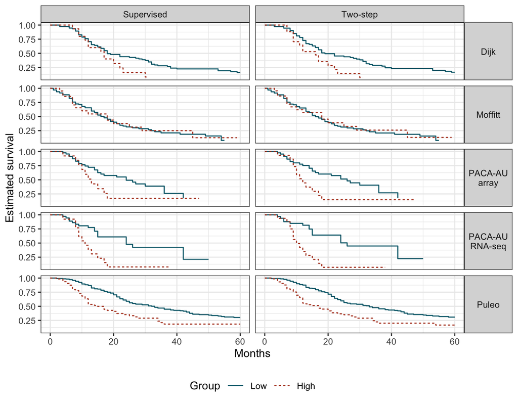

Figure 6: External Kaplan–Meier estimates by fixed training cutpoint. Each model uses its own cutpoint. Curves are drawn from saved monthly survival estimates. The numbers at risk are in Appendix C. Model: supervised YFB fit (w_S = 1, 2,218 genes, rank 5) and its two-step comparator.

These fixed groups and the subtype-adjusted associations are exploratory. Differences between high-versus-low hazard ratios also reflect differences in the patients assigned to each group.

### 4.9.2 Program stability in training folds

For the rank-5 fit, we call a program a main prognostic program when its standardized coefficient is at least 0.25 of the largest, it accounts for at least 5% of the signed risk-score variance and it is survival-active in at least four of the five training folds.

Table 17: Main prognostic programs of the supervised training fit. The ratio is $|\beta_k| \mathrm{SD}(YF_k)$ relative to the largest program. The signed share is $\mathrm{Cov}(\eta_k, \eta)/\mathrm{Var}(\eta)$. Active folds count training folds in which a loading matched with absolute correlation at least 0.7 was survival-active. The precision share is an upper bound on survival’s median share of the loading precision. Model: supervised YFB fit (w_S = 1, 2,218 genes, rank 5).

| Program | Active | Ratio | Signed share | Active folds | Main program | Precision share |
| --- | --- | --- | --- | --- | --- | --- |
| 2 | Yes | 1.00 | 0.591 | 5 | Yes | 7.0e-07 |
| 3 | No | 0.27 | 0.034 | 3 | No | 2.0e-07 |
| 4 | Yes | 0.56 | 0.141 | 3 | No | 1.2e-06 |
| 5 | Yes | 0.62 | 0.234 | 2 | No | 2.5e-06 |

Program 2 is the one main prognostic program. Programs 4 and 5 were active in 3 and 2 folds. In the saved rank-7 fits of the cross-validated-weight simulation, the coefficient and variance-share criteria marked the planted program as main in 80 of 80 fits and marked 35 of the 36 false-active programs as minor. In the two-step fits of the near-threshold simulation they marked 61 of 128 as minor. Fold stability was not computed in simulation.

### 4.9.3 Mixed-signal simulation

A simulation fitted at rank 7 planted one strong and one near-threshold prognostic program with equal standardized effects at 2,000 genes.

Table 18: Mixed-signal simulation at rank 7, ten datasets per arm. All fits converged and every arm recovered the strong program in every dataset. Precision is the fraction of the 50 genes with the largest absolute fitted loading on the matched program that lie in the planted support. The mean includes datasets whose best match has absolute correlation below 0.7.

| Arm | Near-threshold recovered | Top-50 precision | Validation C |
| --- | --- | --- | --- |
| Two-step | 9/10 | 0.826 | 0.731 |
| Supervised, w_S = 1 | 9/10 | 0.858 | 0.735 |
| Supervised, joint $\beta$, w_S = 1 | 9/10 | 0.860 | 0.734 |
| Supervised, w_S = 5 | 2/10 | 0.346 | 0.667 |

At $w_S = 1$ the supervised and two-step fits recovered the near-threshold program equally often. A fixed $w_S = 5$ lost it in most datasets and had lower validation C.

### 4.9.4 Recovery across simulation designs

All three designs compared here fit rank 7. The matched two-step fit recovered the planted program in the representative cell of the cross-validated-weight simulation. The largest unit-weight recovery difference in the near-threshold simulation favoured the supervised fit and occurred at the smallest planted share with strong survival (Table 11). In the mixed-signal simulation, the two unit-weight fits had the same near-threshold recovery as the two-step fit. Figure 7 shows the accompanying differences in false activity, convergence and calibration. On PDAC data the loading agreement and the small Cox contribution to loading precision are consistent with an effect through the coefficient fit (Section 4.3).

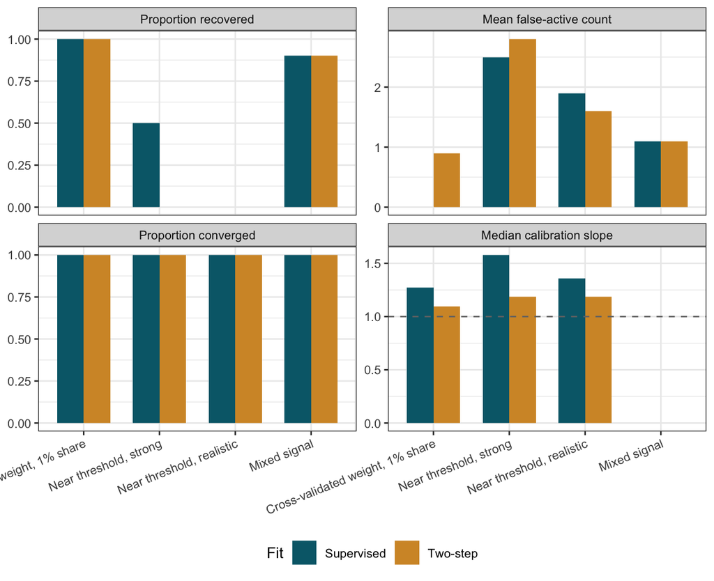

Figure 7: Matched simulation results, all fitted at rank 7. The cross-validated-weight simulation panel shows the 1% planted-variance cell with the cross-validation-selected weight in the block-weighted fit. The near-threshold simulation panel shows the smallest planted share at both survival strengths. The mixed-signal cell reports recovery of the weaker loading and uses one row per fit for false activity and convergence. Calibration slopes were not saved for the mixed-signal experiment.

# 5 Programs of the supervised fit

The programs and external associations in this section are from the rank-5 working model (Section 1.7). Programs 2, 4 and 5 were survival-active. Program 2’s protective pole includes classical epithelial and exocrine genes. Program 4’s adverse pole includes acinar genes, with immune-associated genes at the opposite pole. Program 5 has an adverse coefficient and mitotic and stromal-immune enrichment. These descriptions do not identify a cell type or establish tumor-intrinsic biology.

Table 19: Programs of the supervised training fit. Coefficients are log hazard ratios per SD of the program score, with posterior SDs in parentheses. The positive and negative poles list the genes with the largest signed loadings in each direction. Model: supervised YFB fit (w_S = 1, 2,218 genes, rank 5).

| Program | Coefficient (SD) | Active | Positive pole | Negative pole |
| --- | --- | --- | --- | --- |
| 1 | 0.000 (0.000) | no | ZEB2, MYO5A, CCDC80, TCF4 | RAB25, AP1M2, PKP3, LAD1 |
| 2 | −0.372 (0.083) | yes | METTL7A, ATP2A3, ACACB, PDCD4 | LOXL2, MMP14, LDHA, P4HA1 |
| 3 | 0.101 (0.067) | no | RPS7, RPL6, RPS2, EEF1D | KIAA1211, SYTL2, PLS1, CORIN |
| 4 | 0.209 (0.087) | yes | SERPINA5, CTRB2, CPB1, REG1B | SLAMF6, BANK1, AKNA, EMB |
| 5 | 0.230 (0.084) | yes | UHMK1, ARHGAP5, RAD21, PRKDC | RCN3, CHPF, MXRA8, LOXL1 |

[figure not shown]

Figure 8: Scaled loadings of selected genes across the fitted programs. Asterisks indicate survival-active programs. Model: supervised YFB fit (w_S = 1, 2,218 genes, rank 5).

## 5.1 Enrichment and published signatures

Enrichment was calculated on signed loadings among the modeled genes. The leading sets are in Table 20.

Table 20: Leading enrichment at each pole of the survival-active programs. NES denotes normalized enrichment score. The p-values are adjusted within program. Model: supervised YFB fit (w_S = 1, 2,218 genes, rank 5).

| Program | Collection | Gene set | NES | Adjusted p |
| --- | --- | --- | --- | --- |
| 2 | PDAC | Bailey ADEX | 3.56 | 4.38e-25 |
| 2 | Hallmark | EPITHELIAL MESENCHYMAL TRANSITION | −2.88 | 4.27e-17 |
| 4 | PDAC | Bailey ADEX | 2.75 | 4.55e-25 |
| 4 | Hallmark | ALLOGRAFT REJECTION | −2.40 | 4.09e-06 |
| 5 | PDAC | DeSurv stromal-immune | 2.78 | 1.20e-26 |
| 5 | Hallmark | EPITHELIAL MESENCHYMAL TRANSITION | −2.26 | 2.09e-09 |

Spearman correlations with published signatures were computed within series using the available standardized expression genes. In the pooled training data, Program 2 was inversely associated with the Moffitt basal-like signature, and Program 4 was positively associated with the Bailey ADEX signature. The corresponding external ranges are in Table 21. Correlations between Program 5 and the stromal-immune signature were weaker. These descriptive associations characterize fixed programs.

Table 21: Spearman correlations with selected subtype and stromal signatures. The external interval is the range of point estimates across series. PurIST uses the saved basal-like probabilities. Model: supervised YFB fit (w_S = 1, 2,218 genes, rank 5).

| Program | Signature | Training | External | External PurIST |
| --- | --- | --- | --- | --- |
| 2 | Moffitt basal-like | −0.68 | −0.74 to −0.69 | −0.66 to −0.45 |
| 4 | Bailey ADEX | 0.73 | 0.50 to 0.77 | 0.05 to 0.50 |
| 5 | DeSurv stromal-immune | 0.18 | −0.08 to 0.14 | −0.20 to −0.00 |

The loadings of the supervised fit and of the $w_S = 0$ fit agreed at $|r| = 1.000$ for every matched program (Section 4.3).

## 5.2 Evidence for the individual programs

Program 2 combines the clearest external direction agreement with survival activity in 5 training folds. Its protective pole is associated with classical epithelial and exocrine expression. Its adverse pole includes hypoxia and glycolysis genes. The separate external Cox estimates agree in direction with its training coefficient across all scored series.

Program 4 was active in 3 training folds. Its positive pole includes acinar genes and its negative pole includes immune-associated genes. Its external estimates follow the training direction across all five series (Table 22).

Program 5 had an adverse full-fit coefficient and enrichment for mitotic and stromal-immune signatures. It was active in 2 training folds. Its pooled external HR per training SD was 0.91 (donor-clustered 95% CI 0.80 to 1.04), opposite in direction to its training coefficient, and 3 of the 5 series had HRs below one. Its biological interpretation is exploratory. Its activity in only 2 training folds (Section 4.9.2) shows the same instability.

## 5.3 External program associations and risk groups

Separate external Cox regressions give descriptive associations per series SD of each active program score of the rank-5 fit. The numbers of estimates in the training direction, in program order, were 5, 5, 2 of 5. These estimates are marginal. The training coefficients condition on the other program scores.

Table 22: External program associations from separate Cox regressions. Entries are hazard ratios and Wald intervals per SD of the program score within series. Model: supervised YFB fit (w_S = 1, 2,218 genes, rank 5).

| Series | Program 2 | Program 4 | Program 5 |
| --- | --- | --- | --- |
| Dijk | 0.64 (0.49 to 0.83) | 1.15 (0.92 to 1.44) | 0.75 (0.60 to 0.94) |
| Moffitt | 0.90 (0.73 to 1.12) | 1.02 (0.82 to 1.27) | 0.90 (0.72 to 1.12) |
| PACA-AU array | 0.80 (0.60 to 1.08) | 1.50 (1.10 to 2.05) | 1.12 (0.82 to 1.51) |
| PACA-AU RNA-seq | 0.72 (0.52 to 1.00) | 1.76 (1.21 to 2.57) | 1.43 (0.95 to 2.15) |
| Puleo | 0.72 (0.60 to 0.85) | 1.21 (1.04 to 1.41) | 0.96 (0.84 to 1.10) |

Kaplan–Meier curves use within-series tertiles of the fixed risk score or fixed program scores of the supervised fit. Program scores are oriented using the training coefficients. The tertiles describe relative ranking within each series. They use a different set of cutpoints in each series.

[figure not shown]

Figure 9: External Kaplan–Meier curves for tertiles of the fixed supervised risk score, with numbers at risk. Model: supervised YFB fit (w_S = 1, 2,218 genes, rank 5).

[figure not shown]

Figure 10: External Kaplan–Meier curves by tertile of the Program 2 score oriented in the adverse training direction, with numbers at risk. Model: supervised YFB fit (w_S = 1, 2,218 genes, rank 5).

[figure not shown]

Figure 11: External Kaplan–Meier curves by tertile of the Program 4 score oriented in the adverse training direction, with numbers at risk. Model: supervised YFB fit (w_S = 1, 2,218 genes, rank 5).

[figure not shown]

Figure 12: External Kaplan–Meier curves by tertile of the Program 5 score oriented in the adverse training direction, with numbers at risk. Model: supervised YFB fit (w_S = 1, 2,218 genes, rank 5).

# 6 Discussion

## 6.1 Interpretation

The working model, the supervised YFB fit ($w_S = 1$, 2,218 genes, rank 5), had cross-validated training concordance 0.655 and a mean external concordance of 0.630. Linking survival to the latent scores instead of the projection changed neither number by more than 0.01. For the supervised YFB fit ($w_S = 1$, 2,218 genes, rank 5), the external concordance difference from the two-step fit was small and its interval included zero. Its estimated loadings correlated 1.000 with the unsupervised loadings at the unit survival weight. DeSurv and elastic-net Cox trained on the same patients had the concordance differences and intervals shown in Table 16. The joint coefficient fit accounts for posterior loading uncertainty and uses a shrinkage prior. Calibration slopes of the rank-5 fit and the two-step fit differed by less than their standard errors in every series. The calibration slope is the coefficient of a Cox regression of held-out survival on the fitted risk score, and a slope of one means the fitted risk differences have the observed size.

In the rank-7 simulation cells with consistent recovery, the two-step fit already recovered the prognostic program. The near-threshold simulations isolated a setting where supervision could change discovery. Recovery and concordance improved when survival was strong, while the differences were smaller at realistic survival strength. Methylation alone, on the matched TCGA patients, had concordance close to 0.5, below expression in every comparison but mostly within two standard errors. It added no survival-active program, although a few of its programs are not explained by the expression programs.

## 6.2 Limitations

The gene screen, the input scaling, pooling without a cohort indicator and the starting-value constraints were chosen with external concordance among the evidence before the current selection procedure, and every external series informed at least one of the choices recorded in the audit (Section 2.2). Training cross-validation now supports the screen and the scaling and selected rank 5 (Section 4.7). Because the external series informed the screen and scaling first, the external results still describe a model whose setup those cohorts helped choose. The rank and screen comparisons were repeated over five random partitions of the same 273 patients. Four of the five partitions selected the same rank, so the choices depend little on how patients are assigned to folds, but it does not measure sampling variability. The PACA-AU array and RNA-seq records both contribute to the pooled estimate. The donor bootstrap and the donor-clustered HR intervals account for their shared donors while retaining both series in the estimand. DeSurv used its published settings rather than a new search on our training folds. All five supervised training folds converged at rank 5.

In the rank-7 simulations the coefficients at $w_S = 1$ are attenuated at the larger gene count. These studies use a common simulation generator. The simulation comparing the two survival links issued R warnings whose messages were not saved. The methylation comparison has 144 patients and screened and imputed its CpGs before the folds were split. Its CpG–gene correlations are not adjusted for purity.

## 6.3 Continuing work

Proposed supervision weights include a power on the Cox partial likelihood chosen to match the information in a correctly specified model, downweighting expression and normalizing the likelihood terms. Each would be compared in simulation, on recovery of the planted program, calibration slopes, convergence and the risk-score contribution of programs that match no planted program, before application to the real data.

The working model uses rank 5, the projection link, point-Laplace priors on the scores and loadings and a Normal prior on each coefficient (Section 3). The joint model for expression and methylation remains in development (Section 3.4). Its open problem is balancing the data types when CpG sites far outnumber genes, which a power on the reconstruction likelihood does not solve. Weighting methylation only in the score update and summarizing CpG sites by region are the next candidates, followed by joint fits at 10,000 and 100,000 sites judged mainly on the programs they find. Later choices will use simulation and training data as described in Section 2.2.

# Appendix A. Model derivation

The canonical single-modality procedure uses training expression $Y$ and survival times and indicators. It returns posterior moments of $L$, $F$ and $\beta$, gene precisions and the tracked variational objective.

1. Center and scale the input according to the training preprocessing recipe. Initialize the factorization using a truncated singular value decomposition of the resulting $Y$.
2. Compute the posterior mean and variance of $\eta$. Re-expand the Cox partial log-likelihood about the current mean predictor, using the diagonal curvature to obtain a working normal-means objective.
3. For each program, update $\beta_k$ using the first and second moments of $YF_k$. Update $L_k$ from the expression residual. Update the entries of $F_k$ using both likelihood contributions and refresh the projected scores within the loading update. Use empirical Bayes normal-means fits for the prior parameters.
4. Update the gene-specific noise precisions. Record the monitored objective including the weighted Cox term and the Kullback–Leibler terms. Rescale nonzero programs to unit training projection SD and check the relative change in the objective.
5. In each external series, apply the fixed projection loadings and coefficients to the available training genes. Harrell’s concordance uses the direction learned from training survival.

The full derivation gives the update formulas, the balance of expression and survival information and the numerical checks. The companion `verify_derivation.R` evaluates individual updates against the expected objective.

# Appendix B. Changes since the November 6 version

This version reports the rank-5 working model and its rebuilt external comparisons, risk groups and program exhibits. It adds the prior comparisons, methylation analysis, survival-link comparison, training-only screen and rank analysis, weight refit and descriptive multimodal comparison. The prior and input-scaling comparisons use the rank-7 reference. The simulation exhibits keep their designs, which fit rank 7.

# Appendix C. Program matching, comparator and risk-group details

Table 23: Programs of the supervised YFB fit (w_S = 1, 2,218 genes, rank 5) matched to the rank-7 reference. r is the correlation of the two fits’ program scores over the 273 training patients, and the next column gives the largest absolute correlation with any other rank-7 program. Overlap counts shared genes among the 25 largest loadings at the positive and negative poles. z is the coefficient divided by its posterior SD.

| Program | r | Next best \|r\| | Top-25 overlap (+ / −) | z, rank 5 | z, rank 7 |
| --- | --- | --- | --- | --- | --- |
| 1 | 0.995 | 0.45 | 16 / 18 | 0.0 | 0.0 |
| 2 | 0.993 | 0.45 | 14 / 21 | −4.5 | −4.8 |
| 3 | 0.944 | 0.25 | 19 / 14 | 1.5 | 3.0 |
| 4 | 0.924 | 0.30 | 19 / 21 | 2.4 | 1.9 |
| 5 | 0.988 | 0.07 | 22 / 23 | 2.8 | 2.8 |

Table 24: External discrimination and calibration by series. Concordance intervals are the saved series-level bootstrap intervals. Calibration is the Cox slope with its standard error. The paired donor-level comparison appears in the main text. Model: supervised YFB fit (w_S = 1, 2,218 genes, rank 5) and its two-step comparator. PurIST, elastic-net Cox and DeSurv are separate comparators trained on the same patients.

| Series | Model | Records | Events | C (95% CI) | Slope (SE) |
| --- | --- | --- | --- | --- | --- |
| Dijk | Supervised | 90 | 81 | 0.599 (0.530 to 0.667) | 0.74 (0.38) |
| Dijk | Two-step | 90 | 81 | 0.599 (0.533 to 0.668) | 0.68 (0.33) |
| Dijk | PurIST | 90 | 81 | 0.640 (0.574 to 0.706) | 0.98 (0.29) |
| Dijk | Elastic-net Cox | 90 | 81 | 0.616 (0.545 to 0.685) | 0.84 (0.36) |
| Dijk | DeSurv | 90 | 81 | 0.604 (0.532 to 0.679) | 0.45 (0.18) |
| Moffitt | Supervised | 123 | 83 | 0.538 (0.458 to 0.608) | 0.35 (0.36) |
| Moffitt | Two-step | 123 | 83 | 0.538 (0.460 to 0.611) | 0.33 (0.34) |
| Moffitt | PurIST | 123 | 83 | 0.569 (0.500 to 0.637) | 0.37 (0.26) |
| Moffitt | Elastic-net Cox | 123 | 83 | 0.562 (0.486 to 0.636) | 0.49 (0.39) |
| Moffitt | DeSurv | 123 | 83 | 0.558 (0.480 to 0.634) | 0.46 (0.26) |
| PACA-AU array | Supervised | 63 | 38 | 0.664 (0.573 to 0.756) | 0.83 (0.35) |
| PACA-AU array | Two-step | 63 | 38 | 0.666 (0.574 to 0.757) | 0.74 (0.30) |
| PACA-AU array | PurIST | 63 | 38 | 0.579 (0.467 to 0.685) | 0.20 (0.56) |
| PACA-AU array | Elastic-net Cox | 63 | 38 | 0.645 (0.545 to 0.740) | 0.77 (0.38) |
| PACA-AU array | DeSurv | 63 | 38 | 0.642 (0.541 to 0.742) | 0.63 (0.27) |
| PACA-AU RNA-seq | Supervised | 52 | 31 | 0.704 (0.596 to 0.806) | 1.85 (0.48) |
| PACA-AU RNA-seq | Two-step | 52 | 31 | 0.699 (0.596 to 0.797) | 1.60 (0.41) |
| PACA-AU RNA-seq | PurIST | 52 | 31 | 0.607 (0.502 to 0.718) | 0.76 (0.41) |
| PACA-AU RNA-seq | Elastic-net Cox | 52 | 31 | 0.634 (0.536 to 0.736) | 1.29 (0.45) |
| PACA-AU RNA-seq | DeSurv | 52 | 31 | 0.630 (0.516 to 0.741) | 0.67 (0.25) |
| Puleo | Supervised | 288 | 181 | 0.645 (0.600 to 0.687) | 1.07 (0.21) |
| Puleo | Two-step | 288 | 181 | 0.651 (0.607 to 0.695) | 0.97 (0.19) |
| Puleo | PurIST | 288 | 181 | 0.602 (0.551 to 0.649) | 0.58 (0.19) |
| Puleo | Elastic-net Cox | 288 | 181 | 0.638 (0.595 to 0.681) | 0.97 (0.21) |
| Puleo | DeSurv | 288 | 181 | 0.633 (0.588 to 0.676) | 0.58 (0.14) |

Table 25: Numbers at risk for the fixed-cutpoint curves. Entries are low-risk / high-risk counts by time in months. Model: supervised YFB fit (w_S = 1, 2,218 genes, rank 5) and its two-step comparator.

| Model | Series | 0 | 12 | 24 | 36 | 48 | 60 |
| --- | --- | --- | --- | --- | --- | --- | --- |
| Supervised | Dijk | 75 / 15 | 53 / 9 | 33 / 2 | 20 / 0 | 15 / 0 | 9 / 0 |
| Two-step | Dijk | 73 / 17 | 53 / 9 | 33 / 2 | 20 / 0 | 15 / 0 | 9 / 0 |
| Supervised | Moffitt | 101 / 22 | 57 / 11 | 22 / 6 | 9 / 3 | 6 / 1 | 0 / 0 |
| Two-step | Moffitt | 100 / 23 | 56 / 12 | 22 / 6 | 9 / 3 | 6 / 1 | 0 / 0 |
| Supervised | PACA-AU array | 50 / 13 | 33 / 6 | 17 / 2 | 4 / 2 | 0 / 0 | 0 / 0 |
| Two-step | PACA-AU array | 47 / 16 | 33 / 6 | 17 / 2 | 4 / 2 | 0 / 0 | 0 / 0 |
| Supervised | PACA-AU RNA-seq | 39 / 13 | 26 / 5 | 11 / 1 | 2 / 1 | 1 / 0 | 0 / 0 |
| Two-step | PACA-AU RNA-seq | 36 / 16 | 26 / 5 | 11 / 1 | 2 / 1 | 1 / 0 | 0 / 0 |
| Supervised | Puleo | 223 / 65 | 183 / 32 | 106 / 18 | 67 / 7 | 45 / 5 | 29 / 4 |
| Two-step | Puleo | 213 / 75 | 176 / 39 | 103 / 21 | 65 / 9 | 43 / 7 | 29 / 4 |

# Appendix D. Sensitivity to the priors

Both comparisons use the rank-7 reference (Section 1.7) and compare priors with each other, not each prior against an absolute standard. Their full results are in `docs/findings/2026-11-12-lf-prior-comparison-findings.md`, `docs/findings/2026-11-12-lf-prior-followup-findings.md` and `docs/findings/2026-11-12-beta-prior-comparison-findings.md`.

## Priors on the scores and loadings

The current model uses point-Laplace priors on $L$ and $F$ with expression z-scored within each cohort. The alternative is a point-exponential prior, which keeps every score and loading nonnegative, as in a nonnegative matrix factorization. It needs nonnegative input, so expression is divided by each gene’s within-cohort standard deviation without centering, and the Cox projection is centered on the training data. Everything else is the rank-7 reference’s: $w_S = 1$, a Normal coefficient prior, $K = 7$ without pruning, at most 300 sweeps and tolerance $10^{-5}$. The simulation uses the three variance cells of the fixed-weight simulation at 2,000 genes and the strong-survival cell of the near-threshold simulation at a planted share of 0.05%, with 10 datasets each. The planted scores and loadings are exponential, so the truth favors neither prior. The training comparison uses the five folds of Section 4.2 on the pooled 273 patients and counts only pairs of patients from the same cohort.

In simulation the point-exponential prior recovered the planted program as often as point-Laplace, and more often near the detection threshold (8 against 5 of 10), and every fit converged (Table 26). The point-exponential prior also marked more programs survival-active that matched no planted program, with means of 2.6 to 4.3 per fit against 0.0 to 3.0 for point-Laplace. Such programs are expected, and in the shifted-input fits, where their size was measured, their coefficients were mostly a tenth to a quarter of the planted program’s.

Table 26: Point-Laplace and point-exponential priors on the scores and loadings in simulation at 2,000 genes. Entries give point-Laplace first and point-exponential second. Recovered and converged are counts of datasets. False-active is the mean number of false-active programs per fit. Validation C and the calibration slope are medians over datasets. The 0.05% cell is the strong-survival cell of the near-threshold simulation.

| Planted share | Recovered | False-active programs | Converged | Validation C | Calibration slope |
| --- | --- | --- | --- | --- | --- |
| 0.05% | 5 / 8 | 3.0 / 2.6 | 10 / 10 | 0.832 / 0.839 | 1.58 / 1.26 |
| 0.25% | 10 / 10 | 0.9 / 3.0 | 10 / 10 | 0.947 / 0.940 | 1.45 / 1.39 |
| 1% | 10 / 10 | 0.1 / 4.0 | 10 / 10 | 0.974 / 0.971 | 2.16 / 1.82 |
| 5% | 10 / 10 | 0.0 / 4.3 | 10 / 10 | 0.987 / 0.982 | 3.23 / 2.07 |

Table 27: Priors on the scores and loadings in five-fold training cross-validation. Concordance counts only pairs of patients from the same cohort. The difference from the current model is paired over folds, with its standard error. Convergence is within 300 sweeps. Survival-active programs are the range over folds. Cohort correlation is the largest absolute correlation of a program’s training scores with cohort membership over folds. Under strata the cohort offset is absorbed by the stratified baseline hazard.

| Prior and input | Mean C | Difference (SE) | Folds converged | Survival-active programs | Cohort correlation |
| --- | --- | --- | --- | --- | --- |
| Point-Laplace, z-scores within cohort, rank 7 | 0.658 |  | 3/5 | 2 to 4 | 0.05 |
| Point-exponential, divided by within-cohort SD | 0.573 | −0.085 (0.031) | 0/5 | 0 | 0.998 |
| Point-exponential, divided by within-cohort SD, cohort strata | 0.628 | −0.030 (0.015) | 0/5 | 3 to 4 | 0.998 |
| Point-exponential, shifted z-scores | 0.635 | −0.023 (0.008) | 1/5 | 2 to 4 | 0.05 |
| Point-exponential, within-patient ranks | 0.615 | −0.043 (0.016) | 0/5 | 2 | 1.000 |

## Prior on the survival coefficients

The current model gives each coefficient its own Normal prior. The alternatives are a point-Laplace and a point-normal prior, either of which can set a coefficient exactly to zero. A prior with a point mass cannot be estimated from one coefficient, so both are shared across the seven programs. A shared Normal prior separates the effect of sharing from that of sparsity. All other settings, the simulation cells and the folds are those of the comparison above, with point-Laplace priors on the scores and loadings.

The four priors gave nearly the same fits (Table 28). The sparse priors lowered false activity slightly where the planted program was clear, to 0.3 against 0.9 at a share of 0.25%. Median calibration slopes differed by at most 0.03 between priors outside the 5% cell. In training cross-validation the shared point-Laplace prior lowered concordance by 0.008 (SE 0.002), and the shared point-normal prior by 0.002 (SE 0.004). Under the shared point-normal prior, the posterior probability that a coefficient is nonzero was between 0.94 and 1.00 for all seven programs in the full training fit, so it did not single out the 3 survival-active programs. In simulation the mean number of programs per fit with an inclusion probability above 0.5 was 1.3 at a share of 0.25% and 1.0 at the larger shares, so the prior picked out the planted program alone when that program was clear. Near the threshold it was 4.2. The Normal prior is kept.

Table 28: Coefficient priors in simulation at 2,000 genes and in five-fold training cross-validation. Point-Laplace priors on the scores and loadings throughout. Simulation entries give the planted programs recovered and the mean number of false-active programs per fit. Every simulated fit converged. Training concordance counts pairs within cohort, and the difference from the Normal prior is paired over folds.

| Measure | Normal, rank 7 | Shared point-Laplace | Shared point-normal | Shared Normal |
| --- | --- | --- | --- | --- |
| Simulation, 0.05% share: recovered, false-active | 5, 3.0 | 5, 3.3 | 4, 3.5 | 4, 4.1 |
| Simulation, 0.25% share: recovered, false-active | 10, 0.9 | 10, 0.3 | 10, 0.3 | 10, 1.5 |
| Simulation, 1% share: recovered, false-active | 10, 0.1 | 10, 0.0 | 10, 0.0 | 10, 0.4 |
| Simulation, 5% share: recovered, false-active | 10, 0.0 | 10, 0.0 | 10, 0.0 | 10, 0.0 |
| Training CV: mean C | 0.658 | 0.649 | 0.656 | 0.651 |
| Difference from Normal (SE) |  | −0.008 (0.002) | −0.002 (0.004) | −0.007 (0.004) |
| Survival-active programs per fold | 2.6 | 2.4 | 2.4 | 2.6 |
| Folds converged | 3/5 | 3/5 | 3/5 | 3/5 |

# References

Cox, D. R. 1972. “Regression Models and Life-Tables.” *Journal of the Royal Statistical Society: Series B (Methodological)* 34 (2): 187–202. https://doi.org/10.1111/j.2517-6161.1972.tb00899.x.

Efron, Bradley, and Robert J. Tibshirani. 1993. *An Introduction to the Bootstrap*. Chapman & Hall.

Harrell, Frank E., Robert M. Califf, David B. Pryor, Kerry L. Lee, and Robert A. Rosati. 1982. “Evaluating the Yield of Medical Tests.” *JAMA* 247 (18): 2543–46. https://doi.org/10.1001/jama.1982.03320430047030.

Rashid, Naim U., Xianlu L. Peng, Chong Jin, et al. 2020. “Purity Independent Subtyping of Tumors (PurIST), a Clinically Robust, Single-Sample Classifier for Tumor Subtyping in Pancreatic Cancer.” *Clinical Cancer Research* 26 (1): 82–92. https://doi.org/10.1158/1078-0432.CCR-19-1467.

Willwerscheid, Jason, Peter Carbonetto, and Matthew Stephens. 2025. “ebnm: An R Package for Solving the Empirical Bayes Normal Means Problem Using a Variety of Prior Families.” *Journal of Statistical Software* 114 (3): 1–32. https://doi.org/10.18637/jss.v114.i03.

Young, Amber M., Alisa Yurovsky, Xianlu Laura Peng, Jen Jen Yeh, Didong Li, and Naim U. Rashid. 2026. “Survival-Guided Matrix Factorization Identifies Reproducible Prognostic Programs in Pancreatic Cancer.” https://github.com/rashidlab/DeSurv-paper.